# Airplane Detection using Haar Cascades

## Problem

I have been given a dataset of 102, 1024x1024 satellite images of airports. Alongside the images I have a JSON file that contains the bounding box for each of the airplanes. There are a total of 1092 airplanes in the dataset. My job is to develop a model to reliably detect these airplanes.

By examining the photos, I came to realize that the shape of these airplanes is pretty simple, and applying basic feature matrices over the images might be appropriate to distinguish the airplanes.

## Haar Features

Haar features are like convolution kernels, that consider adjacent rectangular regions at a specific location in a detection window. They calculate a sum of based on the pixel intensities in every region examined and the type of feature applied. They are like the features learned by a CNN, however, they come pre-defined. Based on the maz size of the window of interest, the features can have the following shapes, but in different resolutions. The number of features examined grows exponentially. For example, for a 24x24 window, there are 160,000+ features to examine. Below is a selection of Haar-like features:

[figure not shown]

My hypothesis is that applying these filters, I would be able to reliably tell airplanes apart from their background.

## Model

I will be using a cascade classifier. This classifier consists of multiple stages. In each of the stages, the model moves over a different sized window over the image, and applies all the respective features on that image. If the window examined contains the object of desire (e.g. an airplane), and a statistic calculated over applied feature signals a positive (i.e. usually a threshold of 50%+), then it saves that feature. The result of the model is an XML file that contains the set of "most successful features" for each of the stages.

### Model assumption

The assumption is that applying some Haar-like feature will predict the presence of an object sufficiently, such that a combination of those features (which in themselves would be weak predictors) would produce reliable results. The Haar cascade is basically a decision-tree, where the direction of branching is guided by the saved features for each stage.

### Strengths and Weaknesses

#### Key Strengths

1. Model is really fast to deploy. Applying the saved features (i.e. calculating the *integral image* is really fast. Allows for real time use, such as face detection.
2. Really simple algorithm.
3. Trained model size is very little (i.e. less than 132KB for a 20 stage 24x24 window size).

#### Key Weaknesses

1. Training time increases exponentially with increased window size (due to the exponentially increasing number of features)
2. The basic OpenCV algorithm only accepts grayscale images, so information is lost.
3. It can only function with a fixed aspect ratio scan window. This is a problem when objects get distorted due to perspective. But this is not a big problem for me, for the fixed perspective of satellite photos.

## Pre-processing

I will perform a couple pre processing steps:

```python
from google.colab import drive
drive.mount('/content/drive')
```

```
Go to this URL in a browser: https://accounts.google.com/o/oauth2/auth?client_id=947318989803-6bn6qk8qdgf4n4g3pfee6491hc0brc4i.apps.googleusercontent.com&redirect_uri=urn%3aietf%3awg%3aoauth%3a2.0%3aoob&response_type=code&scope=email%20https%3a%2f%2fwww.googleapis.com%2fauth%2fdocs.test%20https%3a%2…

Enter your authorization code:
··········
```

```python
#load dependencies
import json
import os
import shutil
import matplotlib.pyplot as plt
import numpy as np
import cv2
import random

'''
Create directory environment for Haar Cascades.
'''

if not os.path.isdir("/content/drive/My Drive/Haar_Cascade/"):
  os.mkdir("/content/drive/My Drive/Haar_Cascade/")
if not os.path.isdir("/content/drive/My Drive/Haar_Cascade/positive_folder/"):
  os.mkdir("/content/drive/My Drive/Haar_Cascade/positive_folder/")
if not os.path.isdir("/content/drive/My Drive/Haar_Cascade/negative_folder/"):
  os.mkdir("/content/drive/My Drive/Haar_Cascade/negative_folder/")

json_path = "/content/drive/My Drive/dataset/airport_chips/"
planes_path = "/content/drive/My Drive/dataset/airport_crop/"
positive_path="/content/drive/My Drive/Haar_Cascade/positive_folder/"
negative_path="/content/drive/My Drive/Haar_Cascade/negative_folder/"
```

```python
"""
Load, format and augment negative images
"""
negative_sample_path="/content/drive/My Drive/dataset/negative_img/"
for i,negative_sample in enumerate(os.listdir(negative_sample_path)):
    img = cv2.imread(negative_sample_path+negative_sample)
    gray_image = cv2.cvtColor(img, cv2.COLOR_BGR2GRAY)
    resized_image= cv2.resize(gray_image,(150,150))

    resized_rotate1=cv2.rotate(resized_image,cv2.ROTATE_90_CLOCKWISE)
    resized_rotate2=cv2.rotate(resized_image,cv2.ROTATE_90_COUNTERCLOCKWISE)
    resized_rotate3=cv2.rotate(resized_image,cv2.ROTATE_180)
    cv2.imwrite(negative_path + str(i)+".png", resized_image)
    cv2.imwrite(negative_path + str(i)+"r1"+".png", resized_rotate1)
    cv2.imwrite(negative_path + str(i)+"r2"+".png", resized_rotate2)
    cv2.imwrite(negative_path + str(i)+"r3"+".png", resized_rotate3)
```

```python
"""
Crop positive images and save them into positives folder.
"""

for i, json_file in enumerate(os.listdir(json_path)):
    f = open(json_path+json_file) #open json file
    tags = json.load(f)
    f.close()
    img = cv2.imread(planes_path+tags["imagePath"])
    points=[]
    for sh in tags["shapes"]:
        points.append(sh["points"])

    x=[(i[0][0],i[1][0]) for i in points]
    y=[(i[0][1],i[1][1]) for i in points]

    for k in range(len(x)):
      x1,x2=x[k]
      y1,y2=y[k]
      x1=int(x1)
      x2=int(x2)
      y1=int(y1)
      y2=int(y2)
      crop_img=img[min([y1,y2]):max([y1,y2]),min([x1,x2]):max([x1,x2])]
      savename=str(i)+"_"+str(k)+".png"
      gray_image = cv2.cvtColor(crop_img, cv2.COLOR_BGR2GRAY)
      cv2.imwrite(positive_path + savename, gray_image)
```

```python
'''
Create folder structure and info files for training.
'''

bg_path=("/content/drive/My Drive/Haar_Cascade/")

def create_info1():

  writepath=bg_path+"planes.info"
  mode="w+"
  with open(writepath,mode) as f:
    pass
  for i in os.listdir(positive_path):
    img = cv2.imread(positive_path+i)
    height, width, channels = img.shape
    dim=f' 1 0 0 {width} {height}\n'
    line="positive_folder/"+i+dim
    with open(writepath,'a') as f:
      f.write(line)

def create_info2():
  writepath=bg_path+"bg.txt"
  mode="w+"
  with open(writepath,mode) as f:
    pass
  for i in os.listdir(negative_path):
    line="negative_folder/"+i+"\n"
    with open(writepath,'a') as f:
      f.write(line)

create_info1()
create_info2()
```

```python
#number of negatives
flist=os.listdir("/content/drive/My Drive/Haar_Cascade/negative_folder")
n=len(flist)
print(n)
```

```
5000
```

```python
#create positive .vec file using cv2 commands
%cd "/content/drive/My Drive/Haar_Cascade/"
!pwd
! opencv_createsamples -info planes.info -num 2000 -vec planes.vec
```

```
/content/drive/My Drive/Haar_Cascade
/content/drive/My Drive/Haar_Cascade
Info file name: planes.info
Img file name: (NULL)
Vec file name: planes.vec
BG  file name: (NULL)
Num: 2000
BG color: 0
BG threshold: 80
Invert: FALSE
Max intensity deviation: 40
Max x angle: 1.1
Max y angle: 1.1
Max z angle: 0.5
Show samples: FALSE
Width: 24
Height: 24
Max Scale: -1
Create training samples from images collection...
Done. Created 2000 samples
```

```python
#clear directories before training
shutil.rmtree("/content/drive/My Drive/Haar_Cascade/data/")
if not os.path.isdir("/content/drive/My Drive/Haar_Cascade/data/"):
  os.mkdir("/content/drive/My Drive/Haar_Cascade/data")
```

## Training Model

In the below cell I train the model. Which took over 8 hours on Colab's standard 2-core Xeon 2.2GHz. Luckily, the segmentation of the cascade into stages, allows us to pause training if interrupted, and pick up from where we left off.

```python
#train cascade
! opencv_traincascade -data data -vec planes.vec -bg bg.txt -numPos 1000 -numNeg 2000 -numStages 20 -w 24 -h 24 -featureType HAAR
```

```
---------------------------------------------------------------------------------
Training parameters are pre-loaded from the parameter file in data folder!
Please empty this folder if you want to use a NEW set of training parameters.
---------------------------------------------------------------------------------
PARAMETERS:
cascadeDirName: data
vecFileName: planes.vec
bgFileName: bg.txt
numPos: 1000
numNeg: 2000
numStages: 20
precalcValBufSize[Mb] : 1024
precalcIdxBufSize[Mb] : 1024
acceptanceRatioBreakValue : -1
stageType: BOOST
featureType: HAAR
sampleWidth: 24
sampleHeight: 24
boostType: GAB
minHitRate: 0.995
maxFalseAlarmRate: 0.5
weightTrimRate: 0.95
maxDepth: 1
maxWeakCount: 100
mode: BASIC
Number of unique features given windowSize [24,24] : 162336

Stages 0-17 are loaded

===== TRAINING 18-stage =====
<BEGIN
POS count : consumed   1000 : 1093
NEG count : acceptanceRatio    2000 : 1.592e-05
tcmalloc: large alloc 1073741824 bytes == 0x55ed82d4c000 @  0x7fafe98bc1e7 0x7fafe8a8f382 0x7fafe8b8e21b 0x55ed7bb51608 0x55ed7bb51d42 0x55ed7bb51e1a 0x55ed7bb5b1a9 0x55ed7bb47fff 0x7fafe7d52b97 0x55ed7bb48c1a
tcmalloc: large alloc 1948057600 bytes == 0x55edc2d4c000 @  0x7fafe98bc1e7 0x7fafe8a8f382 0x7fafe8aafe15 0x7fafe8aaff21 0x55ed7bb516fb 0x55ed7bb51d42 0x55ed7bb51e1a 0x55ed7bb5b1a9 0x55ed7bb47fff 0x7fafe7d52b97 0x55ed7bb48c1a
Precalculation time: 36
+----+---------+---------+
|  N |    HR   |    FA   |
+----+---------+---------+
|   1|        1|        1|
```

[output cut: 198 more lines]

```
+----+---------+---------+
|  49|    0.996|    0.546|
+----+---------+---------+
|  50|    0.996|    0.517|
+----+---------+---------+
|  51|    0.996|   0.5285|
+----+---------+---------+
|  52|    0.996|   0.5055|
+----+---------+---------+
|  53|    0.996|   0.5145|
+----+---------+---------+
|  54|    0.996|     0.49|
+----+---------+---------+
END>
Training until now has taken 0 days 1 hours 49 minutes 51 seconds.
```

```python
#set up classifier
plane_cascade=cv2.CascadeClassifier("/content/drive/My Drive/Haar_Cascade/data/cascade.xml")
```

- **scaleFactor** – Parameter specifying how much the image size is reduced at each image scale.
- **minNeighbors** – Parameter specifying how many neighbors each candidate rectangle should have to retain it.
- **minSize** - Parameter specifying minimum object size.
- **maxSize** - Parameter specifying minimum object size.

Changing these variables one engages in a tradeoff of False Positives and accurate predictions. I find that the below specified values work best for this application.

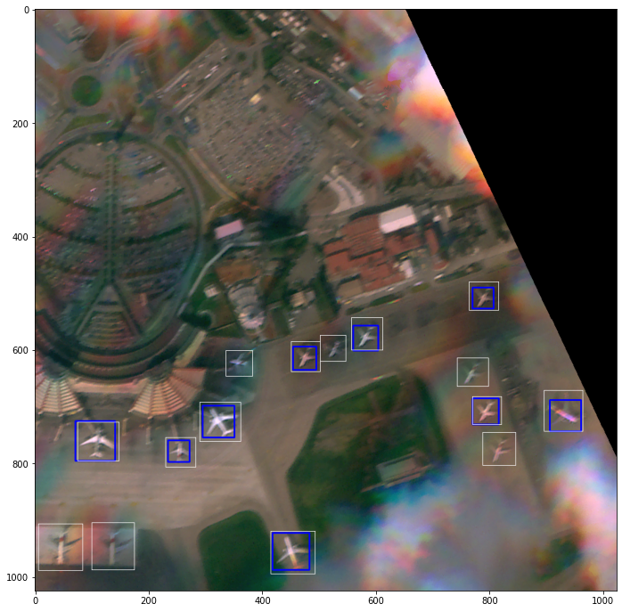

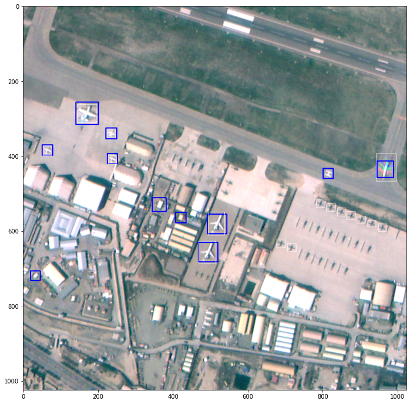

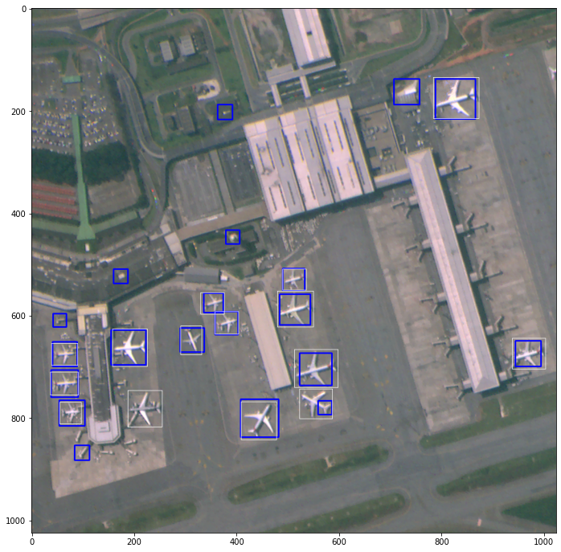

```python
'''
Here I display a couple of examples of the classifier,
to provide visual evidence of its work.

'''

#fine tuned details
scalefactor=1.15
mNeighbors=8

def display_result(img,json_path):
  gray=cv2.cvtColor(img,cv2.COLOR_BGR2GRAY)
  planes = plane_cascade.detectMultiScale(gray,scaleFactor=scalefactor,minNeighbors=mNeighbors,flags=0, minSize=(20,20), maxSize=(160,160))

  #PREDICTED BOUNDING BOXES IN WHITE
  for (x,y,w,h) in planes:
    cv2.rectangle(img,(x,y),(x+w,y+h),(255,0,0),2)
    roi_gray = gray[y:y+h, x:x+w]
    roi_color = img[y:y+h, x:x+w]
    out_rgb = img[:,:,::-1].copy()

  #draw original bounding boxes in WHITE
  f = open(json_path)
  tags = json.load(f)
  f.close()
  points=[]
  for sh in tags["shapes"]:
    points.append(sh["points"])
  for p in points:
    cv2.rectangle(img, (int(p[0][0]),int(p[0][1])), (int(p[1][0]),int(p[1][1])),(255,255,255), 1)
    out_rgb = img[:,:,::-1].copy()

  plt.figure(figsize=(12,12))
  plt.imshow(out_rgb)
  plt.show()

img1=cv2.imread("/content/drive/My Drive/dataset/airport_crop/0.png")
json_path1=("/content/drive/My Drive/dataset/airport_chips/0.json")

img2=cv2.imread("/content/drive/My Drive/dataset/airport_crop/97.png")
json_path2=("/content/drive/My Drive/dataset/airport_chips/97.json")

img3=cv2.imread("/content/drive/My Drive/dataset/airport_crop/54.png")
json_path3=("/content/drive/My Drive/dataset/airport_chips/54.json")

display_result(img1,json_path1)
display_result(img2,json_path2)
display_result(img3,json_path3)
```

In the above where white boxes correspond to the ground truth, whereas blue boxes are our predictions that our HAAR cascade is doing far from perferct.

There are a few false positives as well as false negatives. In the next section I will quanitfy the performance.

## Evaluation

I will use the measure of Intersection of Union. IoU is the ratio of the area of intersection and area of union of the ground truth and predicted bounding boxes. Here, “ground truth bounding box” refers to the actual bounding box whose coordinates are given in our original data set.

- True Positive (TP): A correct detection. Detection with IOU ≥ threshold
- False Positive (FP): A wrong detection. Detection with IOU < threshold
- False Negative (FN): A ground truth not detected
- True Negative (TN): Does not apply. It would represent a corrected misdetection. In the object detection task there are many possible bounding boxes that should not be detected within an image. Thus, TN would be all possible bounding boxes that were corrrectly not detected (so many possible boxes within an image). That's why it is not used in this metrics.

Consequently, I will calculate a precision and recall metric:

- Precision = TP/all detections
- Recall = TP/all ground truths

In this evaluation, I use a IOU threshold of 0.5.

```python
#transform coordinates to specific format
# bbox= [x1,y1,x2,y2]
def flatten(points):
  flat_list = [coo for sublist in points for coo in sublist]
  return flat_list
def reshape(predicted):
  x2=predicted[0]+predicted[2]
  y2=predicted[1]+predicted[3]
  return [predicted[0],predicted[1],x2,y2]

#function to evaluate IoU for a single airplane
def IoU(boxA,boxB):
	# determine the (x, y)-coordinates of the intersection rectangle
	xA = max(boxA[0], boxB[0])
	yA = max(boxA[1], boxB[1])
	xB = min(boxA[2], boxB[2])
	yB = min(boxA[3], boxB[3])
  #print(xA,yA,xB,yB)
	# compute the area of intersection rectangle
	interArea = max(0, xB - xA + 1) * max(0, yB - yA + 1)
	# compute the area of both the prediction and ground-truth
	# rectangles
	boxAArea = (boxA[2] - boxA[0] + 1) * (boxA[3] - boxA[1] + 1)
	boxBArea = (boxB[2] - boxB[0] + 1) * (boxB[3] - boxB[1] + 1)
	# compute the intersection over union by taking the intersection
	# area and dividing it by the sum of prediction + ground-truth
	# areas - the interesection area
	iou = interArea / float(boxAArea + boxBArea - interArea)
	# return the intersection over union value
	return iou

def pointmaker(json_address):
    f = open(json_address)
    tags = json.load(f)
    f.close()
    points=[]
    for sh in tags["shapes"]:
      points.append(flatten(sh["points"]))
    return points
```

```python
#create function for calculating IoU
threshold=0.5
img_path="/content/drive/My Drive/dataset/airport_crop/0.png"
json_address="/content/drive/My Drive/dataset/airport_chips/0.json"

def img_iou(img_path,json_address):
  img=cv2.imread(img_path)
  gray=cv2.cvtColor(img,cv2.COLOR_BGR2GRAY)
  ground_truth=pointmaker(json_address)
  ground_truth=list(reversed(ground_truth))
  predicted=plane_cascade.detectMultiScale(gray,scaleFactor=scalefactor,minNeighbors=mNeighbors,flags=0, minSize=(20,20), maxSize=(180,180))
  predicted=[reshape(i) for i in predicted]
  predicted=sorted(predicted, key=lambda x: x[0],reverse=True)
  true_positive,false_positive=0,0

  for i in predicted:
    isTP=False
    for j in ground_truth:
      iou=IoU(i,j)
      if iou>threshold:
        isTP=True
        true_positive+=1
      elif iou>0 and iou<threshold and isTP:
        false_positive+=1
  return true_positive,false_positive
```

```python
#calculate False and True positives from IOU for every picture
img_paths=[planes_path+i for i in os.listdir(planes_path)]
json_addresses=[json_path+j for j in os.listdir(json_path)]

TP_total,FP_total=0,0
for i,j in zip(img_paths,json_addresses):
  TP,FP=img_iou(i,j)
  TP_total+=TP
  FP_total+FP
print(f"The total of True Positives is {TP_total}")
print(f"The total of False Positives is {FP_total}")

#find total number of planes
total_planes=0
for i, json_file in enumerate(os.listdir(json_path)):
    f = open(json_path+json_file) #open json file
    tags = json.load(f)
    f.close()
    points=[]
    for sh in tags["shapes"]:
        points.append(sh["points"])
    total_planes+=len(points)

print(f"The total number of planes is {total_planes}")
```

[output not shown]

```python
print(f"Our model's recall is {TP_total/total_planes}")
print(f"Our model's precision is {TP_total/(TP_total+FP_total)}")
```

[output not shown]

## Results

A 72% percent recall is not a bad first try. Especially, cause I think there are a few more things I could tune on this model. However, in comparison, state of the art CNNs achieve over 95% recall for multi-object detection. We are definitely not on par. Although, they use much larger datasets.

The 69% percent precision, however, is worrying. This is due to a large number of False Positives. And if our application of the model is such that it avoiding FPs is crucial, then our model is basically useless.

### Improvements for the future

There a couple of things I realized I would do differently as I have finished running this code. I believe these changes would result in improvements of performance and make my model more useful.

#### Reduced Image Size

The smallest airplanes in the dataset are around 30x30 pixels. Based on the HAAR features, a 30% reduction in size should not really affect their detecability. Such a resize would allow me to train the algorithm for longer and perhaps afford a larger than 24x24 window size.

#### More data augmentation

I could have created perhaps twice as many positives from the dataset by further rotations, zooms and other filters. Furthermore, I could have used other publicly available datasets for both positive and negative images. While more positive/negative images would have increased training time, good practice with Haar Cascade suggests that this is the way to go.

#### Include Color channel

An idiosyncratic feature of this dataset is the satellite camera's proprietary lens technology. There is a specific colorful blur effect to be observed with moving planes. I suspect that not discarding color information could increase the performance of the model.